# Romania: Renewable Energy Investments impact on Electricity Prices

## **The Log model**

```r
# create a log-transformed dependent variable
full_data <- full_data %>%
  mutate(log_Electricity_Price = log(Electricity_Price))

# Fit the transformed model
log_model <- lm(log_Electricity_Price ~ Total_Carbon_Cost + GasPrice + Wind + Solar + Hydro + Biomass +
                  FossilFuel_Production + Nuclear, data = full_data)

summary(log_model)
```

```
##
## Call:
## lm(formula = log_Electricity_Price ~ Total_Carbon_Cost + GasPrice +
##     Wind + Solar + Hydro + Biomass + FossilFuel_Production +
##     Nuclear, data = full_data)
##
## Residuals:
##      Min       1Q   Median       3Q      Max
## -0.35905 -0.11887 -0.01093  0.12463  0.41530
##
## Coefficients:
##                           Estimate   Std. Error t value             Pr(>|t|)
## (Intercept)            3.323993128  0.328288247  10.125 0.000000000000000834
## Total_Carbon_Cost      0.000068486  0.000008140   8.413 0.000000000001624086
## GasPrice               0.000008807  0.000002392   3.681             0.000429
## Wind                  -0.000404926  0.000159651  -2.536             0.013227
## Solar                  0.000018224  0.000493967   0.037             0.970666
## Hydro                 -0.000245972  0.000066449  -3.702             0.000400
## Biomass               -0.001815028  0.002644353  -0.686             0.494536
## FossilFuel_Production  0.000406154  0.000064219   6.325 0.000000015316184497
## Nuclear               -0.000139667  0.000195911  -0.713             0.478055
##
## (Intercept)           ***
## Total_Carbon_Cost     ***
## GasPrice              ***
## Wind                  *
## Solar
## Hydro                 ***
## Biomass
## FossilFuel_Production ***
## Nuclear
## ---
## Signif. codes:  0 '***' 0.001 '**' 0.01 '*' 0.05 '.' 0.1 ' ' 1
##
## Residual standard error: 0.1778 on 77 degrees of freedom
## Multiple R-squared:  0.8781, Adjusted R-squared:  0.8655
## F-statistic: 69.37 on 8 and 77 DF,  p-value: < 0.00000000000000022
```

```r
vif(log_model)
```

```
##     Total_Carbon_Cost              GasPrice                  Wind
##              4.789973              3.724576              1.964483
##                 Solar                 Hydro               Biomass
##              2.530237              1.609397              1.784867
## FossilFuel_Production               Nuclear
##              2.300391              1.597273
```

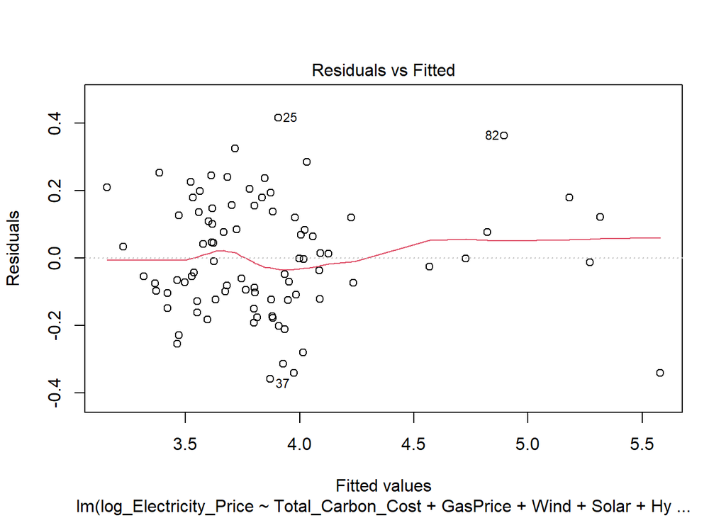

```r
residuals_log <- residuals(log_model)

# Check residuals
plot(log_model, which = 1) # Residuals vs. Fitted Values
```

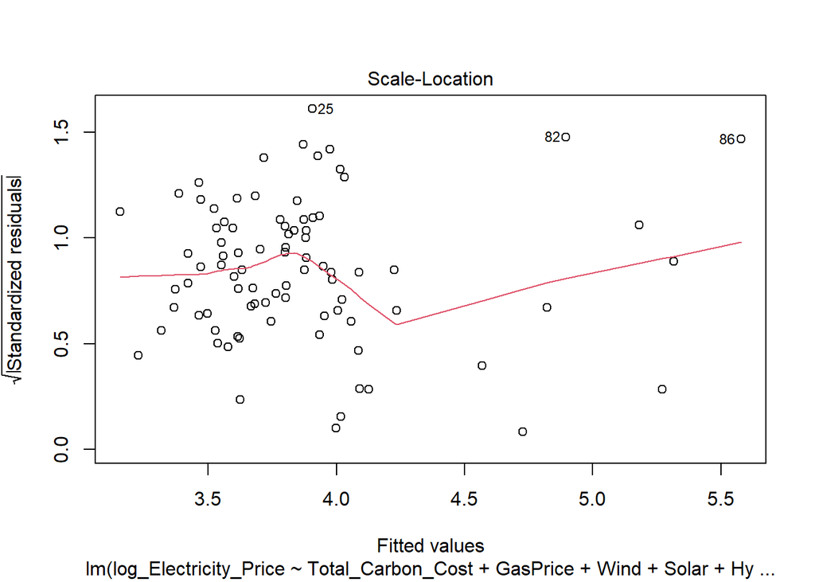

```r
# more random scatter
# the spread of the residuals appears to be more constant across the range of fitted values - addressed heteroscedasticity

plot(log_model, which = 3)  # Scale-Location for the log model #
```

```r
# few outliers still present

bptest(log_model)
```

```
##
##  studentized Breusch-Pagan test
##
## data:  log_model
## BP = 13.747, df = 8, p-value = 0.08861
```

```r
# we do not have enough evidence to reject the null hypothesis of homoscedasticity. Therefore, we can assume that the residuals have constant variance, satisfying the assumption of homoscedasticity - however slight deviations from the rule can still be observed

mean(log_model$residuals)
```

```
## [1] 0.00000000000000000266386
```

```r
shapiro.test(residuals(log_model)) #the residuals are normally distributed
```

```
##
##  Shapiro-Wilk normality test
##
## data:  residuals(log_model)
## W = 0.98926, p-value = 0.7051
```

```r
dwtest(log_model)
```

```
##
##  Durbin-Watson test
##
## data:  log_model
## DW = 0.71165, p-value = 0.0000000000002201
## alternative hypothesis: true autocorrelation is greater than 0
```

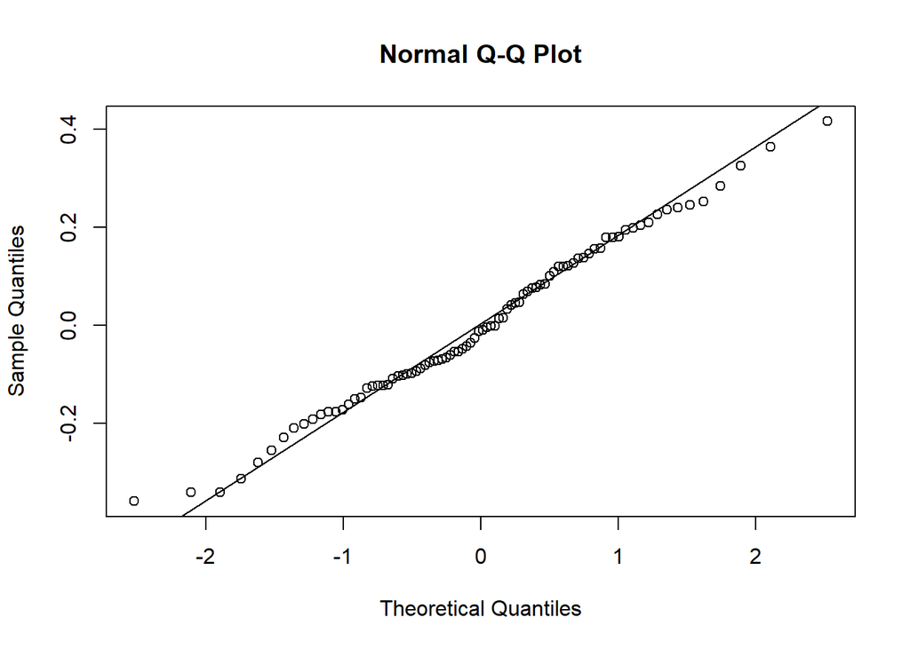

```r
#  The Durbin-Watson statistic is 0.71165, which is significantly less than 2. Additionally, the p-value is extremely small (2.201e-13), indicating strong evidence of positive autocorrelation in the residuals. This violates the assumption of no autocorrelation.

# Q-Q Plot
qqnorm(residuals_log); qqline(residuals_log)
```

```r
# Very Linear: The points in the Q-Q plot fall very closely along the diagonal line. This suggests that the residuals are very close to a normal distribution.
# Minimal Deviations: There are only very minor deviations from the line, even at the tails of the distribution.
# No Obvious Outliers: There are no points that are noticeably far away from the line, suggesting that there are no significant outliers.
```

## **Comparing the models**

AIC (Akaike Information Criterion): AIC measures the goodness of fit of a model while penalizing for the number of parameters. Lower AIC values indicate a better model.

BIC (Bayesian Information Criterion): BIC is similar to AIC but includes a stronger penalty for the number of parameters. Lower BIC values also indicate a better model.

```
## [1] "Baseline Model AIC: 688.934511911447"
```

```
## [1] "Baseline Model BIC: 713.477984873982"
```

```
## [1] "Log-Linear Model AIC: -42.514001929445"
```

```
## [1] "Log-Linear Model BIC: -17.9705289669099"
```

Thus, this reinforces out initial assumptions that using the log-model will be a better fit for our analysis. However, the log-linear model violates the assumption of no autocorrelation, which needs to be addressed.

### **Addressing autocorrealtion issue**

```r
# Create lagged variables
full_data$Lag_Electricity_Price <- dplyr::lag(full_data$Electricity_Price)

log_model_lagged <- lm(log_Electricity_Price ~ Total_Carbon_Cost + GasPrice + Wind + Solar + Hydro + Biomass + FossilFuel_Production +
                         Nuclear + Lag_Electricity_Price, data = full_data)

summary(log_model_lagged)
```

```
##
## Call:
## lm(formula = log_Electricity_Price ~ Total_Carbon_Cost + GasPrice +
##     Wind + Solar + Hydro + Biomass + FossilFuel_Production +
##     Nuclear + Lag_Electricity_Price, data = full_data)
##
## Residuals:
##      Min       1Q   Median       3Q      Max
## -0.31523 -0.11824  0.00507  0.09467  0.46350
##
## Coefficients:
##                           Estimate   Std. Error t value             Pr(>|t|)
## (Intercept)            3.297010131  0.296253146  11.129 < 0.0000000000000002
## Total_Carbon_Cost      0.000055562  0.000007957   6.983       0.000000000999
## GasPrice              -0.000002060  0.000003313  -0.622              0.53598
## Wind                  -0.000458864  0.000145285  -3.158              0.00229
## Solar                  0.000195629  0.000450382   0.434              0.66527
## Hydro                 -0.000181634  0.000062346  -2.913              0.00471
## Biomass               -0.001428334  0.002386119  -0.599              0.55124
## FossilFuel_Production  0.000335653  0.000060007   5.594       0.000000344756
## Nuclear               -0.000101368  0.000177313  -0.572              0.56924
## Lag_Electricity_Price  0.006335923  0.001423337   4.451       0.000029206323
##
## (Intercept)           ***
## Total_Carbon_Cost     ***
## GasPrice
## Wind                  **
## Solar
## Hydro                 **
## Biomass
## FossilFuel_Production ***
## Nuclear
## Lag_Electricity_Price ***
## ---
## Signif. codes:  0 '***' 0.001 '**' 0.01 '*' 0.05 '.' 0.1 ' ' 1
##
## Residual standard error: 0.1601 on 75 degrees of freedom
##   (1 observation deleted due to missingness)
## Multiple R-squared:  0.9036, Adjusted R-squared:  0.8921
## F-statistic: 78.14 on 9 and 75 DF,  p-value: < 0.00000000000000022
```

```r
# even though the model is significant and we introduced a signif lagged variable, we must test the autocor

dwtest(log_model_lagged)
```

```
##
##  Durbin-Watson test
##
## data:  log_model_lagged
## DW = 1.1111, p-value = 0.0000004859
## alternative hypothesis: true autocorrelation is greater than 0
```

```r
# there is still significant autocorrelation
# Since the lagged model did not fully resolve the autocorrelation issue, we need to consider alternative approaches.

N <- nrow(full_data) # Sample size
lag_schwert <- floor(4 * (N / 100)^(2/9)) # Schwert criterion
nw_se_auto <- NeweyWest(log_model, lag = lag_schwert)
coeftest(log_model, vcov = nw_se_auto)
```

```
##
## t test of coefficients:
##
##                            Estimate    Std. Error t value          Pr(>|t|)
## (Intercept)            3.3239931275  0.3838735496  8.6591 0.000000000000545 ***
## Total_Carbon_Cost      0.0000684865  0.0000117784  5.8146 0.000000130917154 ***
## GasPrice               0.0000088066  0.0000055099  1.5983          0.114067
## Wind                  -0.0004049257  0.0001988464 -2.0364          0.045151 *
## Solar                  0.0000182238  0.0007389753  0.0247          0.980389
## Hydro                 -0.0002459716  0.0000873828 -2.8149          0.006193 **
## Biomass               -0.0018150283  0.0044529424 -0.4076          0.684697
## FossilFuel_Production  0.0004061544  0.0001202567  3.3774          0.001150 **
## Nuclear               -0.0001396675  0.0001512050 -0.9237          0.358530
## ---
## Signif. codes:  0 '***' 0.001 '**' 0.01 '*' 0.05 '.' 0.1 ' ' 1
```

```r
# The Newey-West method addresses autocorrelation by adjusting the standard errors to account for the correlation between residuals at different time points. This means that even if the residuals are not independent (which is the case with autocorrelation), the standard errors will still be reliable.

# The Newey-West procedure only affects the standard errors and the associated test statistics and p-values. The estimated regression coefficients themselves remain the same as in the standard OLS output.
```

# **Projection Data Part using the WEM and WAM scenarios**

We initialize and merge the WEM and WAM scenario data, including RES and fossil fuel production, to simulate total electricity supply and RES share over time.

Then, we interpolate monthly gas and carbon prices (2025–2030) based on external expert projections to reflect realistic market conditions in each scenario.

```r
res_capacity_wem$Date <- as.Date(res_capacity_wem$Date)
fossil_fuel_wem$Date <- as.Date(fossil_fuel_wem$Date)

res_capacity_wam$Date <- as.Date(res_capacity_wam$Date)
fossil_fuel_wam$Date <- as.Date(fossil_fuel_wam$Date)


fossil_fuel_wem <- fossil_fuel_wem %>%
  mutate(Scenario = "WEM")

res_capacity_wem <- res_capacity_wem %>%
  mutate(Scenario = "WEM")

fossil_fuel_wam <- fossil_fuel_wam %>%
  mutate(Scenario = "WAM")

res_capacity_wam <- res_capacity_wam %>%
  mutate(Scenario = "WAM")

# 1.left_join separately for WEM
joined_data_wem <- res_capacity_wem %>%
  left_join(fossil_fuel_wem, by = c("Date", "Scenario"))

projection_wem <- joined_data_wem %>% # Start with the joined data
  mutate(Total_Electricity = `Total RES generation (GWh)` + `Total Production Fossil Fuels (Gwh)` + `Nuclear`,
         RES_Share = (`Total RES generation (GWh)` / Total_Electricity) * 100)

# 2.left_join separately for WAM
joined_data_wam <- res_capacity_wam %>%
  left_join(fossil_fuel_wam, by = c("Date", "Scenario"))

projection_wam <- joined_data_wam %>%
  mutate(Total_Electricity = `Total RES generation (GWh)` + `Total Production Fossil Fuels (Gwh)` + `Nuclear`,
         RES_Share = (`Total RES generation (GWh)` / Total_Electricity) * 100)


# Combine both scenarios into one dataset
total_production <- bind_rows(projection_wem, projection_wam) %>%
  arrange(Date, Scenario)



# Calculate midpoint gas prices for monthly projections based on (RPIA, 2023) and (Diallo et al., 2024)
gas_prices <- data.frame(
  Date = as.Date(c("2025-01-01", "2030-12-01")),
  Price_REF = c(36, 30) * 1000,        # Convert EUR/MWh to EUR/GWh
  Price_LowGas = c(35, 29) * 1000      # Convert EUR/MWh to EUR/GWh
)

# Generate monthly dates and calculate midpoints
monthly_dates <- seq(from = as.Date("2025-01-01"), to = as.Date("2030-12-01"), by = "month")
approx_prices <- data.frame(
  Date = monthly_dates,
  Midpoint_GasPrice = approx(gas_prices$Date,
                             (gas_prices$Price_REF + gas_prices$Price_LowGas) / 2,
                             xout = monthly_dates)$y
)

# Merging the scenarios with the projected gas prices
total_production <- total_production %>%
  left_join(approx_prices, by = "Date") %>%
  filter(Date <= as.Date("2030-12-01")) %>%
  arrange(Date, Scenario)


# EU ETS prices based on online sources #

# Known carbon prices for 2025 and 2030 (Dimitrova, 2024) - (Gabin et al., 2023)
known_carbon_prices <- data.frame(
  Date = as.Date(c("2025-01-01", "2030-12-01")),
  Carbon_Price = c(75, 140)  # Midpoint of 2025 and 2030 ranges
)

# Homaio’s expert consensus captures upside risks from supply tightening and financialization. For academic purposes, a midpoint estimate of €75/tCO₂ in 2025 and €140/tCO₂ in 2030 balances these perspectives, though sensitivity analyses should quantify the impact of MSR rule changes and CBAM expansion.

# Interpolate carbon prices for each date in the total_production dataset
total_production <- total_production %>%
  mutate(Carbon_Price = approx(
    x = known_carbon_prices$Date,
    y = known_carbon_prices$Carbon_Price,
    xout = as.numeric(as.Date(Date))
  )$y)
```

We apply the validated log-linear model to forecast electricity prices under WEM and WAM, transforming predictions back to €/MWh for interpretation.

## **WEM Scenario**

```r
# emission factors (t CO2/GWh) based on the NECP Electricity generation capacity (projected)
emission_factors_projected <- list(
  Coal = 334,
  NaturalGas = 205,
  biomass = 19
)

# Separate data by scenario *before* adding exogenous variables

projection_wem_final <- total_production %>%
  filter(Scenario == "WEM") %>%
  mutate(
    GasPrice = Midpoint_GasPrice,
    FossilFuel_Production = `Total Production Fossil Fuels (Gwh)`,
    Carbon_Cost_Coal = `Coal (GWh)` * emission_factors_projected$Coal * Carbon_Price,
    Carbon_Cost_NaturalGas = `NaturalGas (GWh)` * emission_factors_projected$NaturalGas * Carbon_Price,
    Carbon_Cost_biomass = `Biomass` * emission_factors$biomass * Carbon_Price,
    # Total carbon cost (€/GWh)
    Total_Carbon_Cost = (Carbon_Cost_Coal + Carbon_Cost_NaturalGas + Carbon_Cost_biomass) / FossilFuel_Production,
    #  + Carbon_Cost_NaturalGasCHP
    # get the carbon cost per GWh of fossil fuel electricity

    # Handle division by zero (if fossil fuel production is 0)
    Total_Carbon_Cost = ifelse(FossilFuel_Production == 0, 0, Total_Carbon_Cost),
    RES_Capacity_WEM = `Total RES generation (GWh)`
    ) %>%
  arrange(Date)


# Predictions Using the Log-Model
Projection_WEM_Final_Log <- projection_wem_final %>%
  mutate(Predicted_Log_Electricity_Price_WEM = predict(log_model, newdata = .),
         Predicted_Electricity_Price_WEM = exp(Predicted_Log_Electricity_Price_WEM)  # Converting back to original scale
        )
```

## **WAM Scenario**

```r
projection_wam_final <- total_production %>%
  filter(Scenario == "WAM") %>%
  mutate(
    GasPrice = Midpoint_GasPrice,
    FossilFuel_Production = `Total Production Fossil Fuels (Gwh)`,
    Carbon_Cost_Coal = `Coal (GWh)` * emission_factors_projected$Coal * Carbon_Price,
    Carbon_Cost_NaturalGas = `NaturalGas (GWh)` * emission_factors_projected$NaturalGas * Carbon_Price,
    # Carbon_Cost_NaturalGasCHP = `NaturalGas CHP (GWh)` * emission_factors_projected$NaturalGasCHP * Carbon_Price,
    Carbon_Cost_biomass = `Biomass` * emission_factors$biomass * Carbon_Price,
    # Total carbon cost (€/GWh)
    Total_Carbon_Cost = (Carbon_Cost_Coal + Carbon_Cost_NaturalGas + Carbon_Cost_biomass) / FossilFuel_Production,
    #  + Carbon_Cost_NaturalGasCHP
    # get the carbon cost per GWh of fossil fuel electricity

    # handle division by zero (if fossil fuel production is 0)
    Total_Carbon_Cost = ifelse(FossilFuel_Production == 0, 0, Total_Carbon_Cost),
    RES_Capacity_WAM = `Total RES generation (GWh)`
    ) %>%
  arrange(Date)


Projection_WAM_Final_Log <- projection_wam_final %>%
  mutate(Predicted_Log_Electricity_Price_WAM = predict(log_model, newdata = .),
         Predicted_Electricity_Price_WAM = exp(Predicted_Log_Electricity_Price_WAM))
```

Now we can calculate the price difference between WEM and WAM, and decompose the gap using average coefficients and variable differences to understand key drivers.

To visualize we create a clean bar chart to highlight price differences between WEM and WAM in 2025 and 2030, based on scenario-specific predictions.

## **Price Differences between the two scenarios**

```r
# price diff log
price_differences <- Projection_WEM_Final_Log %>%
  select(Date, Predicted_Electricity_Price_WEM) %>%
              left_join(Projection_WAM_Final_Log %>%
  select(Date, Predicted_Electricity_Price_WAM), by = "Date")

#----------- 2030 Log model Price Decomp --------------#

calculate_price_drivers <- function(wam_data, wem_data, wam_model, wem_model, wam_log_model, wem_log_model) {
  wam_2030 <- wam_data %>% filter(format(Date, "%Y") == "2030")
  wem_2030 <- wem_data %>% filter(format(Date, "%Y") == "2030")

  # differences in key variables (break down RES)
  differences <- data.frame(
    Variable = c("Total_Carbon_Cost", "GasPrice", "Wind", "Solar", "Hydro", "Biomass", "FossilFuel_Production", "Nuclear"),
    WAM_value = c(
      mean(wam_2030$Total_Carbon_Cost),
      mean(wam_2030$GasPrice),
      mean(wam_2030$Wind),
      mean(wam_2030$Solar),
      mean(wam_2030$Hydro),
      mean(wam_2030$Biomass),
      mean(wam_2030$FossilFuel_Production),
      mean(wam_2030$Nuclear)
    ),
    WEM_value = c(
      mean(wem_2030$Total_Carbon_Cost),
      mean(wem_2030$GasPrice),
      mean(wem_2030$Wind),
      mean(wem_2030$Solar),
      mean(wem_2030$Hydro),
      mean(wem_2030$Biomass),
      mean(wem_2030$FossilFuel_Production),
      mean(wem_2030$Nuclear)
    )
  )

  differences$Absolute_Difference <- differences$WAM_value - differences$WEM_value

  # Get coefficients and transform log coefficients
  wam_coef <- coef(wam_model)
  wem_coef <- coef(wem_model)
  wam_log_coef <- coef(wam_log_model)
  wem_log_coef <- coef(wem_log_model)

  # Function to transform log coefficient
  transform_log_coef <- function(coef) {
    (exp(coef) - 1) * mean(wem_2030$Predicted_Electricity_Price_WEM) # Use WEM mean price
  }

  # average coefficients (transformed for log model)
  differences$Average_Coefficient <- c(
    mean(c(wam_coef["Total_Carbon_Cost"], wem_coef["Total_Carbon_Cost"])),
    mean(c(wam_coef["GasPrice"], wem_coef["GasPrice"])),
    mean(c(transform_log_coef(wam_log_coef["Wind"]), transform_log_coef(wem_log_coef["Wind"]))),
    mean(c(transform_log_coef(wam_log_coef["Solar"]), transform_log_coef(wem_log_coef["Solar"]))),
    mean(c(transform_log_coef(wam_log_coef["Hydro"]), transform_log_coef(wem_log_coef["Hydro"]))),
    mean(c(transform_log_coef(wam_log_coef["Biomass"]), transform_log_coef(wem_log_coef["Biomass"]))),
    mean(c(wam_coef["FossilFuel_Production"], wem_coef["FossilFuel_Production"])),
    mean(c(wam_coef["Nuclear"], wem_coef["Nuclear"]))
  )

  # price impact
  differences$Price_Impact_Linear <- differences$Absolute_Difference * differences$Average_Coefficient

  differences$Price_Impact_Log <- (exp(differences$Average_Coefficient * differences$Absolute_Difference) - 1) *
    mean(wem_2030$Predicted_Electricity_Price_WEM)


  return(differences %>% arrange(desc(abs(Price_Impact_Linear)))) # You can sort by either linear or log impact
}


price_drivers <- calculate_price_drivers(
  Projection_WAM_Final_Log,
  Projection_WEM_Final_Log,
  baseline_model,
  baseline_model,
  log_model,
  log_model
)

print(price_drivers)
```

```
##                Variable   WAM_value   WEM_value Absolute_Difference
## 1                  Wind  1383.33333  1108.33333            275.0000
## 2               Nuclear  1283.33333   975.00000            308.3333
## 3                 Solar  1079.22523   900.00000            179.2252
## 4     Total_Carbon_Cost 27761.66710 27761.66710              0.0000
## 5              GasPrice 29965.27778 29965.27778              0.0000
## 6                 Hydro  1358.33333  1358.33333              0.0000
## 7               Biomass    41.66667    41.66667              0.0000
## 8 FossilFuel_Production  1125.00000  1125.00000              0.0000
##   Average_Coefficient Price_Impact_Linear Price_Impact_Log
## 1        -0.058231657         -16.0137058       -143.83737
## 2        -0.008324477          -2.5667138       -132.79247
## 3         0.002621287           0.4698008         86.25575
## 4         0.002469911           0.0000000          0.00000
## 5         0.001843251           0.0000000          0.00000
## 6        -0.035375565           0.0000000          0.00000
## 7        -0.260832135           0.0000000          0.00000
## 8         0.016294392           0.0000000          0.00000
```

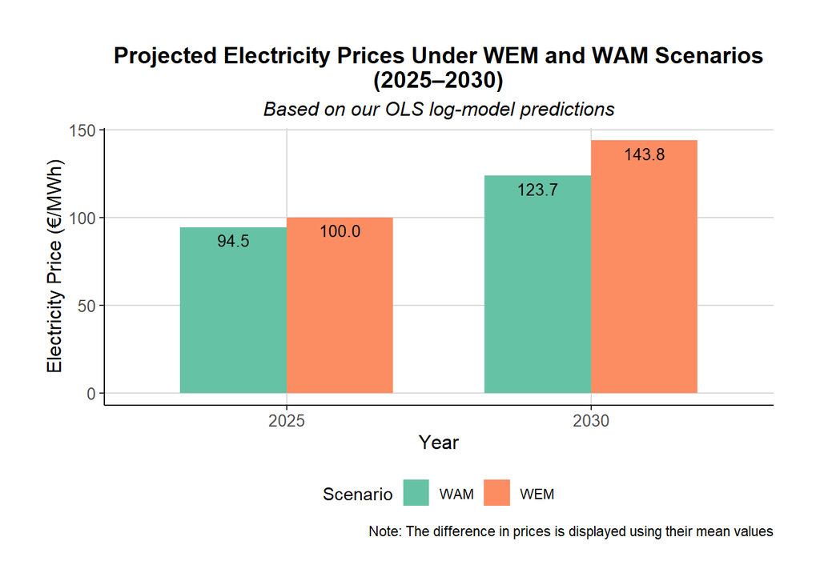

```r
# visualization
comparison_data <- price_differences %>%
  filter(format(Date, "%Y") %in% c("2025", "2030")) %>%
  # just one value per year (to avoid duplicate labels)
  group_by(Year = format(Date, "%Y")) %>%
  summarize(
    WEM = mean(Predicted_Electricity_Price_WEM, na.rm = TRUE),
    WAM = mean(Predicted_Electricity_Price_WAM, na.rm = TRUE)
  ) %>%
  # Convert to long format for ggplot
  tidyr::pivot_longer(
    cols = c(WEM, WAM),
    names_to = "Scenario",
    values_to = "Price_EUR_MWh"
  )


ggplot(comparison_data, aes(x = Year, y = Price_EUR_MWh, fill = Scenario)) +
  geom_bar(stat = "identity", position = "dodge", width = 0.7) +
  scale_fill_brewer(palette = "Set2") +
  labs(
    title = "Projected Electricity Prices Under WEM and WAM Scenarios\n(2025–2030)",
    subtitle = "Based on our OLS log-model predictions",
    x = "Year",
    y = "Electricity Price (€/MWh)",
    fill = "Scenario",
    caption = "Note: The difference in prices is displayed using their mean values"
  ) +
  theme_classic() +
  theme(
    plot.title = element_text(hjust = 0.5, size = 14, face = "bold"),
    plot.subtitle = element_text(hjust = 0.5, size = 12, face = "italic"),
    axis.title = element_text(size = 12),
    axis.text = element_text(size = 10),
    legend.position = "bottom",
    plot.margin = unit(c(1, 1, 1, 1), "cm"),
    panel.grid.major = element_line(color = "gray85"),
    panel.grid.minor = element_blank()
  ) +
  geom_text(
    aes(label = sprintf("%.1f", Price_EUR_MWh)),
    position = position_dodge(width = 0.7),
    vjust = 1.5,
    size = 3.5
  )
```